# Governança Territorial da Inovação e Políticas Públicas de CT&I

Empreendedorismo Tecnológico e Desenvolvimento Territorial · Aula 04

Prof. Dr. Luiz Diego Vidal Santos

## Unidade I Visão geral da aula

**01 · Modelos em hélice:** Hélice Tríplice, Quádrupla e Quíntupla no território.

**02 · Estado Empreendedor:** Mazzucato — socialização do risco vs. privatização do lucro.

**03 · Crítica ao isomorfismo:** Limites da cópia do Vale do Silício e *Smart Specialisation* (Foray).

**04 · Habitats de suporte:** Parques tecnológicos, incubadoras, aceleradoras e NITs.

**05 · Marco Legal de CT&I:** Leis 10.973/2004 e 13.243/2016 e instrumentos regionais.

Propósito formativo Objetivo da aula

Examinar os mecanismos de **governança territorial da inovação**, o papel do Estado e das universidades na criação de mercados e a efetividade de parques tecnológicos, incubadoras e políticas públicas de CT&I.

Hélice Quíntupla Missões · Mazzucato Marco Legal CT&I

**Questão crítica:** Como evitar que habitats de inovação e investimentos públicos se convertam em enclaves isolados da estrutura produtiva regional?

# Modelos em Hélice

## Conceito Da Hélice Tríplice à Quádrupla e Quíntupla

Etzkowitz & Leydesdorff (2000) Hélice Tríplice

- **Universidade:** geração de conhecimento, talento e *spin-offs* (Universidade Empreendedora).
- **Empresa:** produção, absorção tecnológica e escala de mercado.
- **Governo:** regulação, compras públicas, fomento e infraestrutura.
- **Espaços de consenso e inovação:** zonas híbridas onde as três esferas assumem papéis umas das outras.

Carayannis & Campbell (2009; 2010) Hélice Quádrupla e Quíntupla

- **4ª Hélice — Sociedade civil, usuários, mídia e cultura:** legitima demandas sociais e cocria soluções (*Living Labs*).
- **5ª Hélice — Ambiente natural e sustentabilidade socioecológica:** orienta a inovação para a transição ecológica.

**Leitura PLANTERR:** Sem a 4ª e a 5ª hélices, parques e polos tecnológicos correm o risco de se tornarem **enclaves desconectados** do território onde estão instalados.

## Síntese Da Hélice Tríplice à Hélice Quíntupla

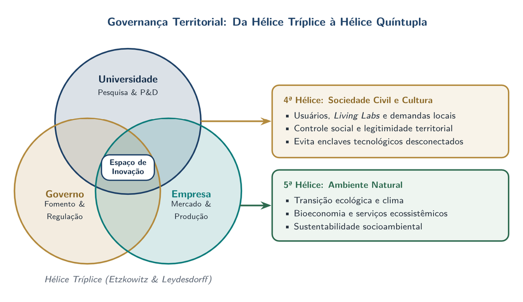

Modelo de governança territorial da inovação integrando Universidade, Empresa, Governo, Sociedade Civil (4ª hélice) e Ambiente Natural (5ª hélice).

Governança territorial: da Hélice Tríplice à Hélice Quíntupla Integração entre Universidade, Empresa, Governo, Sociedade Civil (4ª hélice) e Ambiente Natural (5ª hélice)

A 4ª e a 5ª hélices deslocam o foco da mera transferência tecnológica para a legitimidade territorial e a transição socioecológica.

# O Estado Empreendedor

## Conceito Financiamento de risco e políticas por missões

Mariana Mazzucato (2014) O Estado criador de mercados

- O Estado não apenas “corrige falhas de mercado”: ele **cria e molda mercados** assumindo o risco tecnológico inicial que o capital privado evita.
- **Exemplos históricos:** internet, GPS, telas sensíveis ao toque, biotecnologia inicial e transição energética.
- **Problema da assimetria:** socialização dos riscos na fase de P&D e privatização dos retornos na fase comercial.

Direcionalidade territorial Políticas orientadas por missões (*Missions*)

- Em vez de subsídios genéricos, definir **missões territoriais claras** (descarbonização de cadeias locais, segurança hídrica no Semiárido, bioeconomia florestal).
- **Instrumentos:**
  - Compras públicas de inovação (Encomenda Tecnológica — ETEC);
  - Subvenção econômica direta (FINEP, EMBRAPII, FAPs);
  - Crédito direcionado e fundos de garantia.

# Parques Tecnológicos, Incubadoras e NITs

## Método Habitats de inovação e Marco Legal de CT&I

| Habitat | Público-Alvo | Função Territorial |
| --- | --- | --- |
| **Pré-incubadora** | Ideias, projetos acadêmicos | Validação inicial e modelagem |
| **Incubadora** | *Startups* nascentes | Mentoria, espaço, redução de mortalidade |
| **Aceleradora** | Negócios validados | Tração rápida e acesso a capital |
| **Parque Tecnológico** | Empresas de P&D, ICTs, *spin-offs* | Adensamento de P&D e atração de talentos |

Lei 10.973/2004 e Lei 13.243/2016 Marco Legal de CT&I no Brasil

- Institucionaliza os **Núcleos de Inovação Tecnológica (NITs)** nas universidades e ICTs.
- Permite compartilhamento de laboratórios com empresas, prestação de serviços de P&D e participação minoritária em *spin-offs*.
- Facilita convênios e encomendas tecnológicas no setor público.

# Debate e Caso Comparado

## Crítica Socialização do risco e isomorfismo institucional

1 · Mazzucato vs. visão neoclássica Além das “falhas de mercado”

- A teoria convencional restringe o Estado a mero regulador ou corretor de falhas de mercado.
- **Crítica de Mazzucato:** o Estado atua como investidor de primeiro recurso e direcionador de missões sociotécnicas.
- **Contradição estrutural:** ocorre **socialização do risco** nas fases mais incertas da ciência/tecnologia e **privatização dos lucros** por fundos e corporações na fase comercial.

2 · Especialização Inteligente (Foray, 2015) Crítica ao “isomorfismo do Vale do Silício”

- Tentar clonar parques tecnológicos e fundos de *venture capital* de países centrais em regiões periféricas produz “elefantes brancos” desconectados da estrutura produtiva local.
- A **Especialização Inteligente (*Smart Specialisation*)** exige **descoberta empreendedora endógena** baseada nas vocações reais do território e regulada pela Sociedade Civil (4ª Hélice) e pela Sustentabilidade Ecológica (5ª Hélice).

## Território Parques tecnológicos e leituras (Eixos 3 e 4)

Governança de longo prazo Sucesso vs. “catedrais no deserto”

1. Ancoragem em **competências científicas reais** da região.
2. Articulação orgânica com cadeias produtivas locais (não apenas aluguel de salas).
3. Governança autônoma e estabilidade além de ciclos eleitorais de 4 anos.
4. Fluxo contínuo de projetos vindos de universidades e empresas locais.

Sem demanda produtiva endógena e articulação institucional, infraestrutura física vira imobiliário público ocioso.

Bibliografia fundamental Leituras da Aula 04 e próxima aula (Eixos 3 e 4)

- **ETZKOWITZ, H.; LEYDESDORFF, L.** *The dynamics of innovation: Triple Helix*. Research Policy, 2000.
- **MAZZUCATO, M.** *O Estado empreendedor: desmascarando o mito do setor público vs. setor privado*, 2014.
- **FORAY, D.** *Smart specialisation: opportunities and challenges for regional innovation policy*, 2015.
- **BRASIL.** *Marco Legal de CT&I* (Lei nº 13.243/2016).
- **AUSTIN, J.; STEVENSON, H.; WEI-SKILLERN, J.** *Social and commercial entrepreneurship*. ETP, 2006; **MAIR, J.; MARTÍ, I.** *Social entrepreneurship research*. JWB, 2006.